# Lab - the data science workflow

Adi Sarid

2020-05-06

In this lab we cover the data science work flow. The lab will walk you through the steps performed in a data science project:

- Data import
- Data tidying
- Transformation <-> Visualization <-> Modelling

The lab will also cover the theoretic elements we covered such confidence intervals and hypothesis tests. This lab is to be performed in groups of 3 (i.e., zoom break rooms).

# First exercise - open up a new project.

First, open up a new project. To do this, in RStudio go to:

- File -> New Project -> New Directory -> New Project.

Provide your project directory name (under directory name), and click ok. Note that everything will close and RStudio will open up in a clean window. But don’t worry, you can always view this file by visiting [this link](https://github.com/adisarid/intro_statistics_R/tree/master/labs/Data_science_workflow_lab.Rmd).

Once a new RStudio instance has opened with a clean window of your new project, open up a new RMarkdown, which you will use to answer your questions to this lab by:

- File -> New file -> R Markdown…

Give your RMarkdown file a name and use the html outupt type. In your new RMarkdown file you can delete lines 1-10 and delete everything else in the file (lines 11-31). Try to knit it by clicking ctrl+k.

Now we are ready to do some analysis.

# Second exercise - get to know your data

In this lab we are going to analyze food consumption data from *tidytuesday*. You can read about tidytuesday [here](https://github.com/rfordatascience/tidytuesday) - it’s a github repository which is updated every Tuesday with data freely available for analyzing and sharpening your data analysis skills. Today we will use this dataset: [here](https://github.com/rfordatascience/tidytuesday/blob/master/data/2020/2020-02-18/readme.md).

In groups, find the original source of the data (the nu3.de website within the links) and discuss:

- What is the origin of the data?
- Would you consider the data reliable/trust worthy?
- How was the carbon footprint computed for each food type and country?

Using the `read_csv` function from the `readr` package, read the food consumption data.

- Use the following functions to understand how the data is arranged: `glimpse`, `head`, `View`.
- Comparing the file you read with the original table, in what sense the file you read is more “tidy”?

```r
food_consumption <- readr::read_csv('https://raw.githubusercontent.com/rfordatascience/tidytuesday/master/data/2020/2020-02-18/food_consumption.csv')
glimpse(food_consumption)
```

```
## Rows: 1,430
## Columns: 4
## $ country       <chr> "Argentina", "Argentina", "Argentina", "Argentina", "...
## $ food_category <chr> "Pork", "Poultry", "Beef", "Lamb & Goat", "Fish", "Eg...
## $ consumption   <dbl> 10.51, 38.66, 55.48, 1.56, 4.36, 11.39, 195.08, 103.1...
## $ co2_emmission <dbl> 37.20, 41.53, 1712.00, 54.63, 6.96, 10.46, 277.87, 19...
```

```r
head(food_consumption)
```

```
## # A tibble: 6 x 4
##   country   food_category consumption co2_emmission
##   <chr>     <chr>               <dbl>         <dbl>
## 1 Argentina Pork                10.5          37.2
## 2 Argentina Poultry             38.7          41.5
## 3 Argentina Beef                55.5        1712
## 4 Argentina Lamb & Goat          1.56         54.6
## 5 Argentina Fish                 4.36          6.96
## 6 Argentina Eggs                11.4          10.5
```

**Checkpoint** - make sure you summarize your answers in a convinient way, we are going to discuss them in class.

# Third exercise - visualization, and descriptive statistics of food consumption

In the group, discuss:

- What influences the consumption of various goods (e.g., pork, beef, fish, wheat, etc.). In which countries would you expect to find a low or high consumption of specific products?
- Write down an equivalent formula for the variance. This is a theoretic part, you can write your answer in RMarkdown by enclosing it with the $ characters like this. RMarkdown interprets such test as LaTeX and creates a formula:

$$\sigma^2=\operatorname{Var}(X)=E\left[(X-E[X])^2\right]=\ldots?$$

- Write down two estimates for the variance $\hat{\sigma}^2$ and $s^2$. Which would you prefer to use and why?
- What plot(s) would you use to visualize the distribution of consumption of each food type? you can use the `ggplot2` cheatsheet to consider this. Once you reach a conclusion - create the chart.

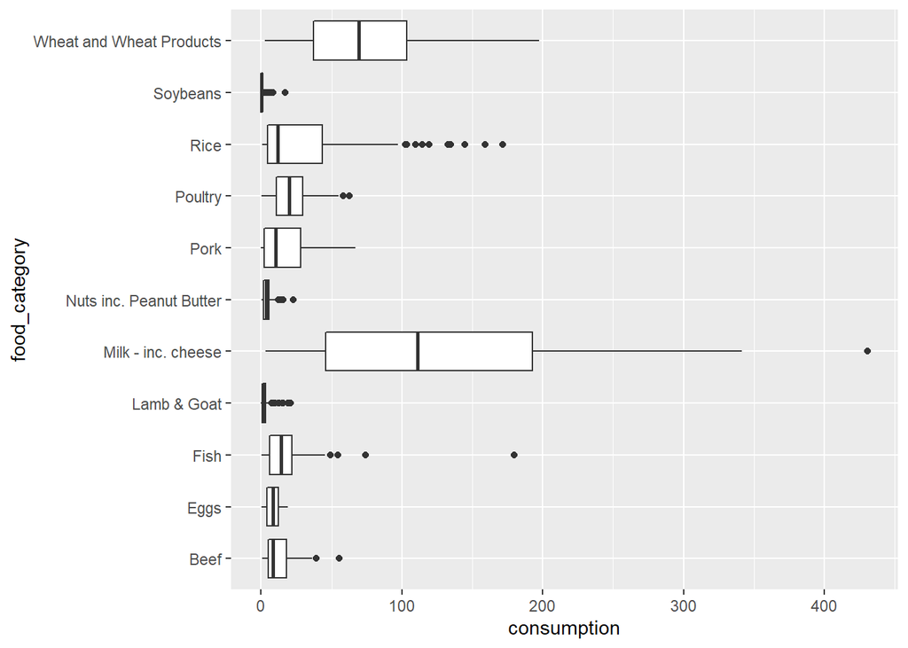

```r
ggplot(food_consumption, aes(x = food_category, y = consumption)) +
   geom_boxplot() + coord_flip()
```

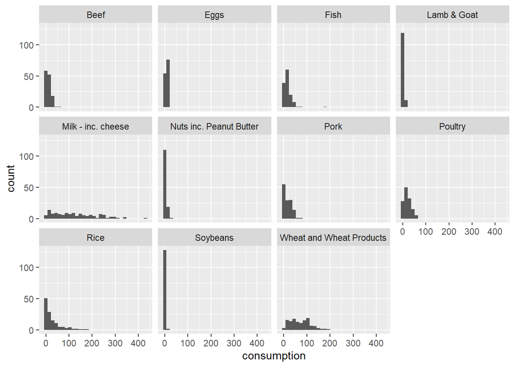

```r
ggplot(food_consumption, aes(x = consumption)) +
   geom_histogram() +
   facet_wrap(~food_category)
```

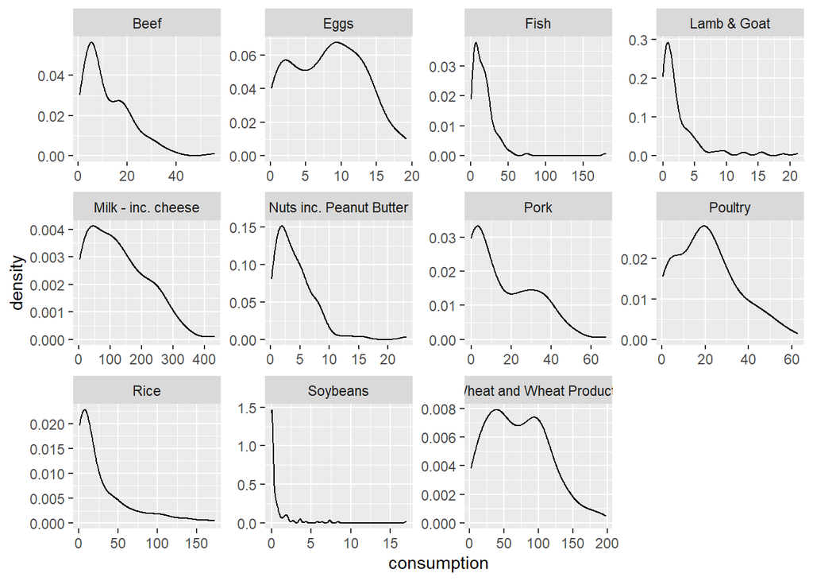

```r
ggplot(food_consumption, aes(x = consumption)) +
   geom_density() +
   facet_wrap(~food_category, scales = "free")
```

- Based on the plot, what products have the highest (or lowest) variance? what is the meaning of having a high (or low) variance in this context of food consumption?
- Verify this by computing the consumption standard deviation of each product, also add to your computation the mean, median and 1st and 3rd quartiles. You can use `group_by` and `summarize` for this.

```r
food_descriptives <- food_consumption %>%
   group_by(food_category) %>%
   summarize(mean = mean(consumption),
             q1 = quantile(consumption, probs = 0.25),
             q2 = median(consumption),
             q3 = quantile(consumption, probs = 0.75),
             sd = sd(consumption)) %>%
   arrange(desc(mean))
food_descriptives
```

```
## # A tibble: 11 x 6
##    food_category               mean    q1      q2     q3    sd
##    <chr>                      <dbl> <dbl>   <dbl>  <dbl> <dbl>
##  1 Milk - inc. cheese       126.    45.8  111.    193.   93.3
##  2 Wheat and Wheat Products  71.5   37.0   69.4   103.   44.2
##  3 Rice                      29.4    4.72  11.9    43.4  37.3
##  4 Poultry                   21.2   10.9   19.9    29.7  14.6
##  5 Fish                      17.3    6.02  14.0    21.9  19.0
##  6 Pork                      16.1    2.09  10.4    28.2  15.7
##  7 Beef                      12.1    5.00   8.28   17.9   9.65
##  8 Eggs                       8.16   3.94   8.42   12.3   5.03
##  9 Nuts inc. Peanut Butter    4.14   1.81   3.50    5.61  3.37
## 10 Lamb & Goat                2.60   0.56   1.33    3.10  3.67
## 11 Soybeans                   0.861  0.01   0.075   0.64  2.08
```

**Checkpoint** - together in class, we’re going to discuss and solve the exercise so far.

# Fourth exercise - modelling - confidence intervals and hypothesis tests of consumption

In this part we will create a number of confidence intervals. Follow these steps in order to answer this question:

- First, decide what kind of confidence interval is to be used (what statistic are you using) and write it down as a formula:

$$T_{\text{df}=n-1} = \frac{\bar{X} - \mu}{S/\sqrt{n}}$$

- And the confidence interval is therefore:

$$\mu\in\bar{X}\pm t_{\alpha/2,n-1}S/\sqrt{n}$$

- Use the tibble you created in the last step of the previous part (`food_descriptives`), to create a confidence interval for all the food categories, with $\alpha=0.05$. Use the following code.

```r
# First find the relevant t for the chosen alpha and the relevant degrees of freedom
t0.05_129 <- qt(p = 0.05/2, df = 129)

# Now use it on the tibble we computed
food_descriptives %>%
   mutate(ci_lower_bound = mean + t0.05_129*sd/sqrt(130),
          ci_upper_bound = mean - t0.05_129*sd/sqrt(130)) %>%
   select(food_category, ci_lower_bound, mean, ci_upper_bound)
```

```
## # A tibble: 11 x 4
##    food_category            ci_lower_bound    mean ci_upper_bound
##    <chr>                             <dbl>   <dbl>          <dbl>
##  1 Milk - inc. cheese              110.    126.            142.
##  2 Wheat and Wheat Products         63.9    71.5            79.2
##  3 Rice                             22.9    29.4            35.9
##  4 Poultry                          18.7    21.2            23.7
##  5 Fish                             14.0    17.3            20.6
##  6 Pork                             13.4    16.1            18.9
##  7 Beef                             10.4    12.1            13.8
##  8 Eggs                              7.29    8.16            9.04
##  9 Nuts inc. Peanut Butter           3.55    4.14            4.72
## 10 Lamb & Goat                       1.96    2.60            3.24
## 11 Soybeans                          0.499   0.861           1.22
```

- Check your result using the `t.test` function for Fish.

```r
fish_vector <- food_consumption %>%
   filter(food_category == "Fish") %>%
   pull(consumption)

t.test(fish_vector)
```

```
##
##  One Sample t-test
##
## data:  fish_vector
## t = 10.366, df = 129, p-value < 2.2e-16
## alternative hypothesis: true mean is not equal to 0
## 95 percent confidence interval:
##  13.98770 20.58645
## sample estimates:
## mean of x
##  17.28708
```

- Formulate a hypothesis test which examines the expected consumption of Fish vs. Pork (with $H_0$ and $H_1$).

$$H_0: \mu_{\text{pork}} = \mu_{\text{fish}}$$
$$H_0: \mu_{\text{pork}} \neq \mu_{\text{fish}}$$

- Assuming that the variance of pork and fish consumption is the same, what test statistic would you use for this hypothesis?

$$T=\frac{\bar{X}_1 - \bar{X}_2 - (\mu_1 - \mu_2)}{S_p\sqrt{1/n_1 + 1/n_2}}$$

$$S_p = \sqrt{\frac{(n_1-1)S_1^2 + (n_2-1)S_2^2}{n_1 + n_2 -2}}$$

With df$=n_1+n_2-2$.

- Is this a paired or unpaired test?
- Conduct the test by computing the test statistic and its p-value. You can do this either directly or with the `t.test` function. However you prefer. If you are using the `t.test`, note that you have to set the `var.equal` argument (to what?).

```r
pork_vector <- food_consumption %>%
   filter(food_category == "Pork") %>%
   pull(consumption)

t.test(x = fish_vector, y = pork_vector, var.equal = T)
```

```
##
##  Two Sample t-test
##
## data:  fish_vector and pork_vector
## t = 0.5377, df = 258, p-value = 0.5912
## alternative hypothesis: true difference in means is not equal to 0
## 95 percent confidence interval:
##  -3.097202  5.423971
## sample estimates:
## mean of x mean of y
##  17.28708  16.12369
```

- How would you have conducted the test if the variances were assumed to be unequal?

```r
t.test(x = fish_vector, y = pork_vector, var.equal = F)
```

```
##
##  Welch Two Sample t-test
##
## data:  fish_vector and pork_vector
## t = 0.5377, df = 249.18, p-value = 0.5913
## alternative hypothesis: true difference in means is not equal to 0
## 95 percent confidence interval:
##  -3.097913  5.424682
## sample estimates:
## mean of x mean of y
##  17.28708  16.12369
```

**Checkpoint** - solving this exercise together in class.

# Fifth exercise - visualizing the relationship between meet products and vegan products

In this final part, we’re going to use visualizations to examine the relationship between meat/dairy and vegan products.

- Reclassify all the `food_category` into two types of products: meet/dairy versus vegan. You can use the definition of the following tibble, along with the `left_join` function, but you will probably need to read about it in the documentation. Another option is to use another function called `case_when` or `recode_factor`.

```r
food_types <- tribble(~food_category, ~food_type,
                      "Beef", "Meat/Dairy",
                      "Eggs", "Meat/Dairy",
                      "Fish", "Meat/Dairy",
                      "Lamb & Goat", "Meat/Dairy",
                      "Milk - inc. cheese", "Meat/Dairy",
                      "Pork", "Meat/Dairy",
                      "Poultry", "Meat/Dairy",
                      "Rice", "Vegan",
                      "Soybeans", "Vegan",
                      "Wheat and Wheat Products", "Vegan",
                      "Nuts inc. Peanut Butter", "Vegan")

food_consumption_reclassified <- food_consumption %>%
   left_join(food_types)
```

- In the result you got, summarize the data such that each country will appear only twice (once for Meat/Dairy and once for Vegan consumption values), with the overall consumption for that type. Select only the `consumption` and `food_type` values. You should be using the functions `group_by` and `summary`.

```r
food_consumption_summarised <- food_consumption_reclassified %>%
   group_by(country, food_type) %>%
   summarize(consumption = sum(consumption))
```

- We would like to create a chart in which each country is a point, the x axis is Meat/dairy and the y-axis is Vegan consumption. What kind of transformations would you need to do on the previous tibble to prepare it for such a plot?
- Try to use `pivot_wider` in order to make that transformation, and use `ggplot` to create the chart.

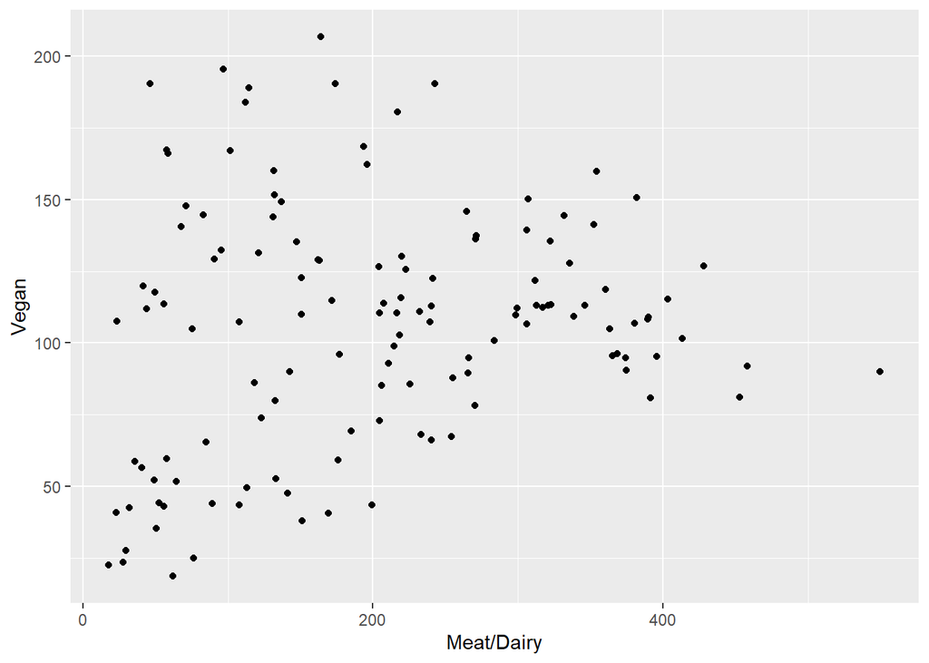

```r
food_consumption_summarised %>%
   ungroup() %>%
   select(country, consumption, food_type) %>%
   pivot_wider(names_from = food_type, values_from = consumption) %>%
   ggplot(aes(x = `Meat/Dairy`, y = Vegan)) +
   geom_point()
```

- Can you identify any relationships between the two variables? (consumption of Meat/Dairy versus consumption of Vegan food?)

**Checkpoint** - Solve exercise together in class.